# Climate and CTI Analysis

Josie Lesage

1/17/2020

# INTRODUCTION

These data were downloaded in another markdown file (“PRISM.rmd”). They represent the interpolated climate data at all sites for which I have community composition datasets.

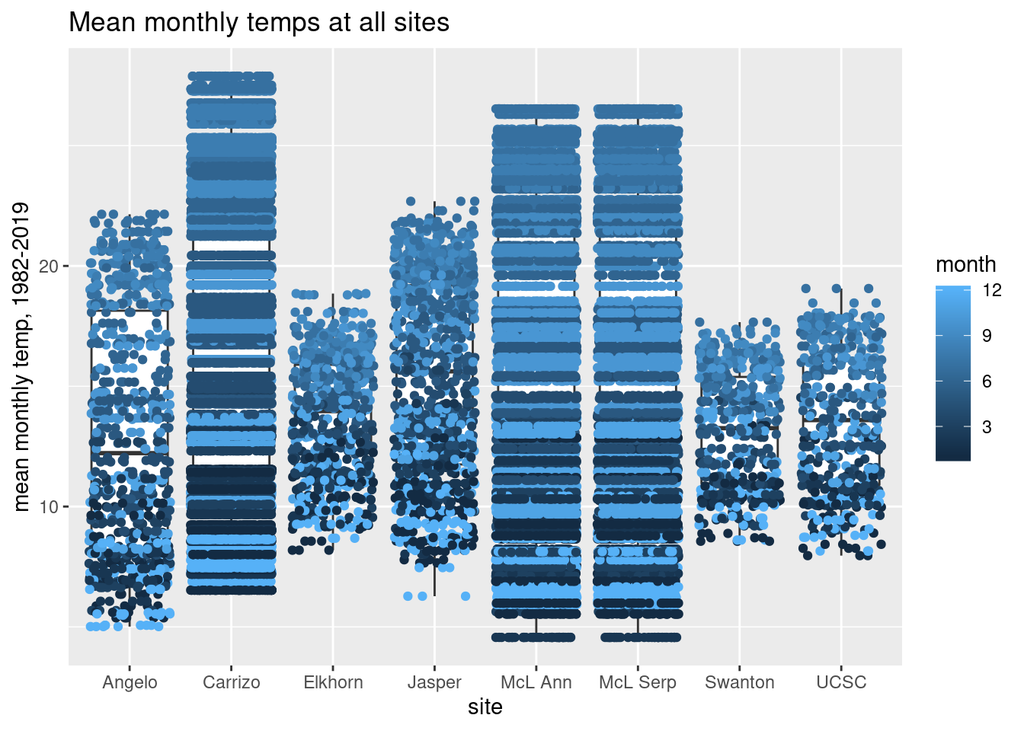

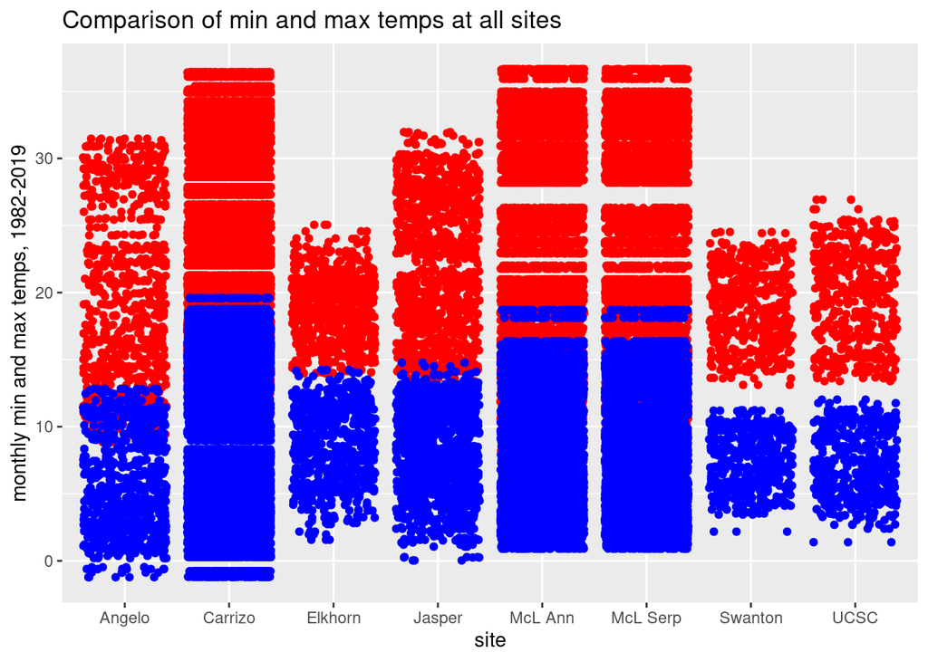

The lines are temperature, and the bars are precip. Thi graph shows the data by water year (oct-sep):

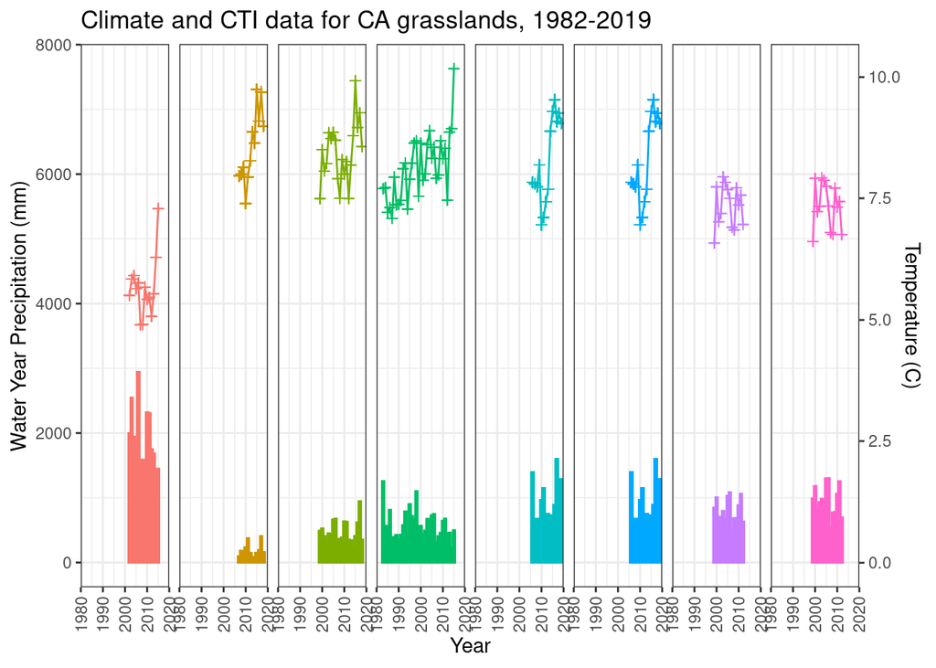

# ANALYSIS

In order to have legs to stand on, we must take a look at the weather history at these sites - this means determining whether there have been directional trends in temperature or precipitation over time.  
One thing to note is that we should only look at the data over the years in which we have community composition data.

## Precipitation Analysis

First, let’s take a look at the change in precipitation over time, since I think that is less likely to be significant for our focal years. Then, we’ll look at our temp. data.

### Overall water year precip

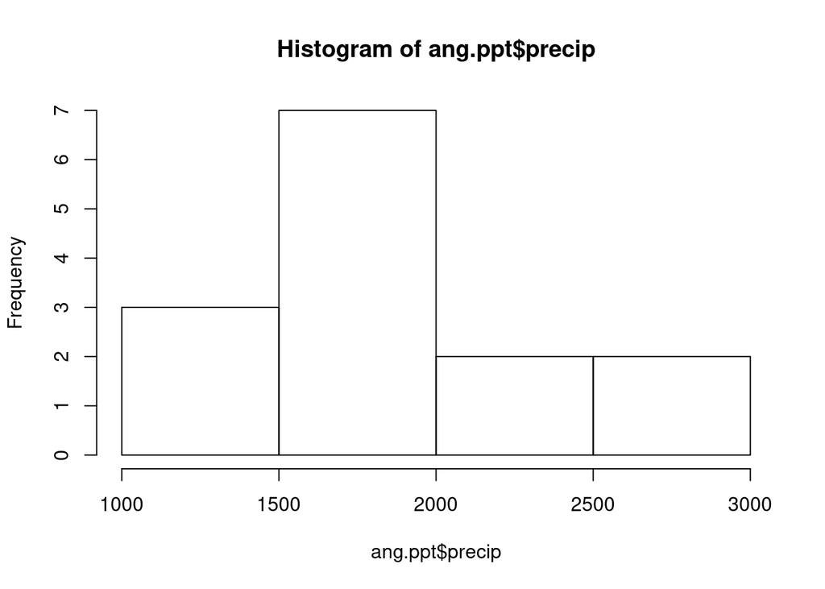

```r
# angelo
ang.ppt <- all.CTI.wtryr %>% filter(site == "Angelo")
hist(ang.ppt$precip)
```

```r
ang.ppt.lm <- lm(precip ~ year,
                    data = ang.ppt)
summary(ang.ppt.lm)
```

```
##
## Call:
## lm(formula = precip ~ year, data = ang.ppt)
##
## Residuals:
##    Min     1Q Median     3Q    Max
## -527.3 -316.5 -127.5  265.4  911.0
##
## Coefficients:
##              Estimate Std. Error t value Pr(>|t|)
## (Intercept) 124135.99   60725.95   2.044   0.0635 .
## year           -60.87      30.23  -2.013   0.0671 .
## ---
## Signif. codes:  0 '***' 0.001 '**' 0.01 '*' 0.05 '.' 0.1 ' ' 1
##
## Residual standard error: 456 on 12 degrees of freedom
## Multiple R-squared:  0.2525, Adjusted R-squared:  0.1902
## F-statistic: 4.053 on 1 and 12 DF,  p-value: 0.06708
```

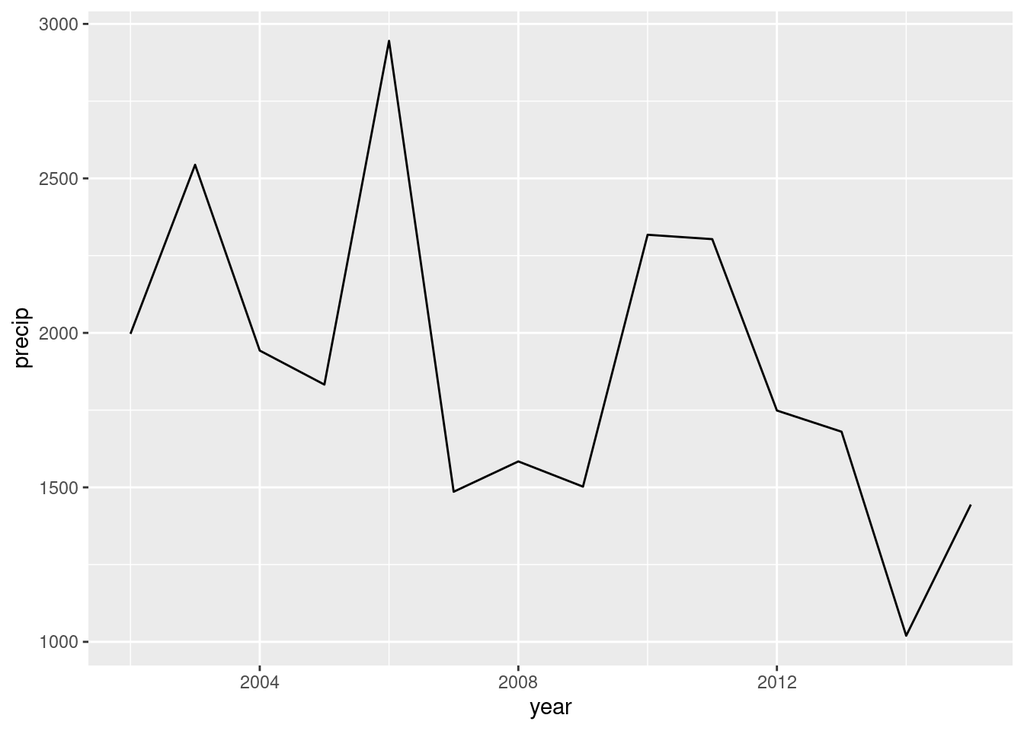

```r
ggplot(ang.ppt, aes(x = year, y = precip)) + geom_line()
```

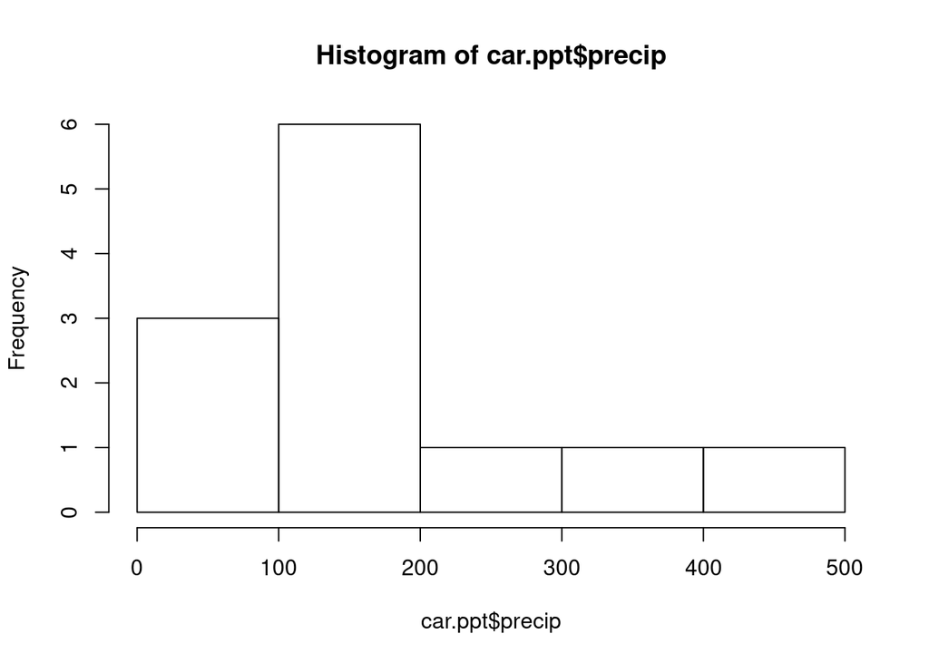

```r
# carrizo
car.ppt <- all.CTI.wtryr %>% filter(site == "Carrizo")
hist(car.ppt$precip)
```

```r
car.ppt.lm <- lm(precip ~ year,
                    data = car.ppt)
summary(car.ppt.lm)
```

```
##
## Call:
## lm(formula = precip ~ year, data = car.ppt)
##
## Residuals:
##     Min      1Q  Median      3Q     Max
## -138.52  -59.47  -25.28   30.26  196.54
##
## Coefficients:
##               Estimate Std. Error t value Pr(>|t|)
## (Intercept) -10685.495  18579.866  -0.575    0.578
## year             5.401      9.232   0.585    0.572
##
## Residual standard error: 110.4 on 10 degrees of freedom
## Multiple R-squared:  0.03309,    Adjusted R-squared:  -0.0636
## F-statistic: 0.3422 on 1 and 10 DF,  p-value: 0.5715
```

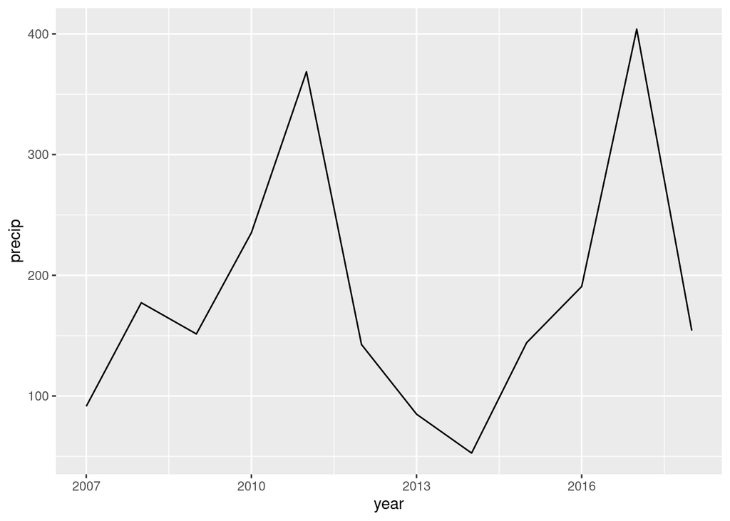

```r
ggplot(car.ppt, aes(x = year, y = precip)) + geom_line()
```

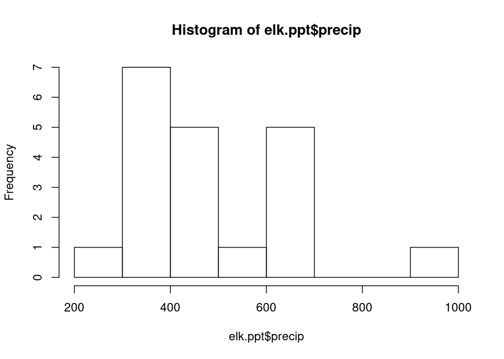

```r
# elkhorn
elk.ppt <- all.CTI.wtryr %>% filter(site == "Elkhorn")
hist(elk.ppt$precip)
```

```r
elk.ppt.lm <- lm(precip ~ year,
                    data = elk.ppt)
summary(elk.ppt.lm)
```

```
##
## Call:
## lm(formula = precip ~ year, data = elk.ppt)
##
## Residuals:
##     Min      1Q  Median      3Q     Max
## -259.19 -118.88  -42.34  123.67  443.56
##
## Coefficients:
##              Estimate Std. Error t value Pr(>|t|)
## (Intercept) -5601.748  13590.966  -0.412    0.685
## year            3.027      6.767   0.447    0.660
##
## Residual standard error: 174.5 on 18 degrees of freedom
## Multiple R-squared:  0.01099,    Adjusted R-squared:  -0.04395
## F-statistic: 0.2001 on 1 and 18 DF,  p-value: 0.66
```

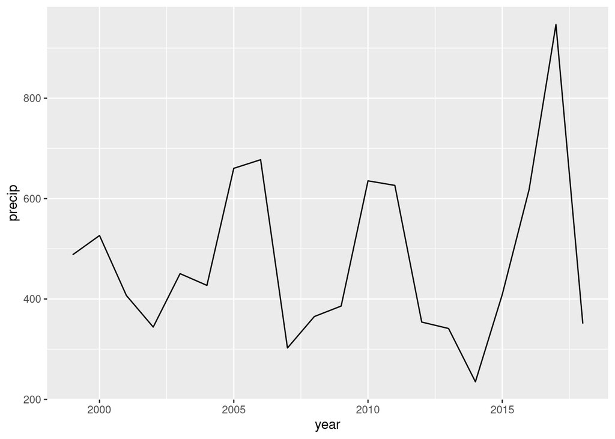

```r
ggplot(elk.ppt, aes(x = year, y = precip)) + geom_line()
```

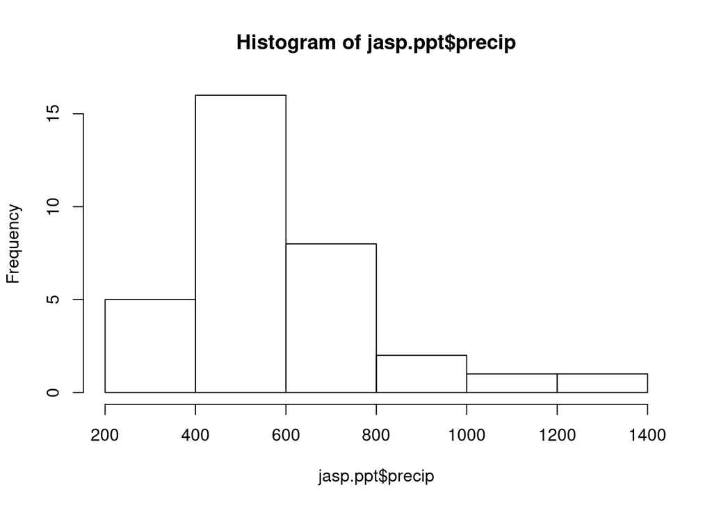

```r
# jasper
jasp.ppt <- all.CTI.wtryr %>% filter(site == "Jasper")
hist(jasp.ppt$precip)
```

```r
jasp.ppt.lm <- lm(precip ~ year,
                    data = jasp.ppt)
summary(jasp.ppt.lm)
```

```
##
## Call:
## lm(formula = precip ~ year, data = jasp.ppt)
##
## Residuals:
##     Min      1Q  Median      3Q     Max
## -296.93 -131.55  -45.17  135.65  584.28
##
## Coefficients:
##              Estimate Std. Error t value Pr(>|t|)
## (Intercept) 12774.514   7933.346   1.610    0.117
## year           -6.102      3.969  -1.538    0.134
##
## Residual standard error: 217.1 on 31 degrees of freedom
## Multiple R-squared:  0.07086,    Adjusted R-squared:  0.04089
## F-statistic: 2.364 on 1 and 31 DF,  p-value: 0.1343
```

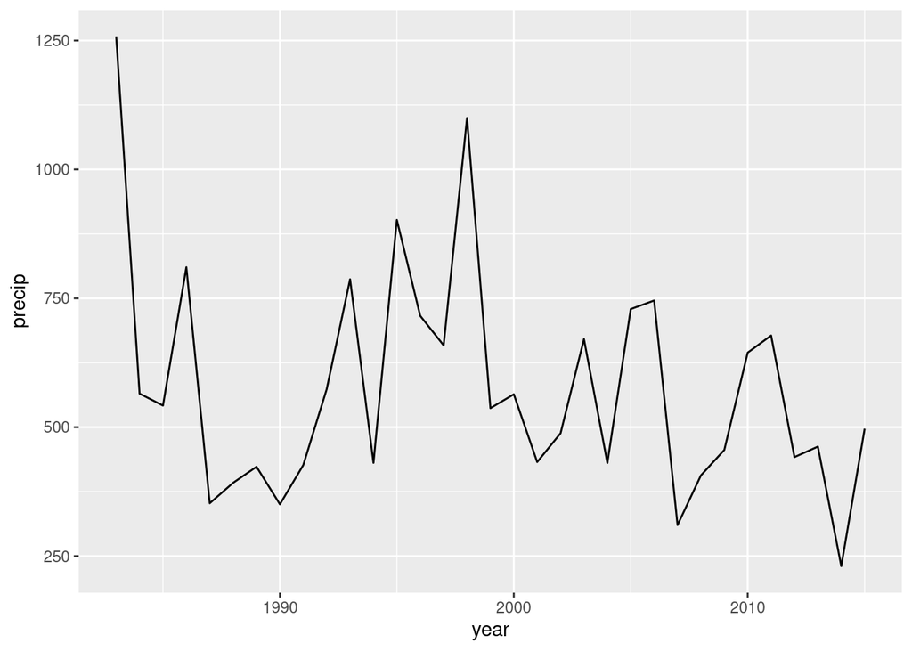

```r
ggplot(jasp.ppt, aes(x = year, y = precip)) + geom_line()
```

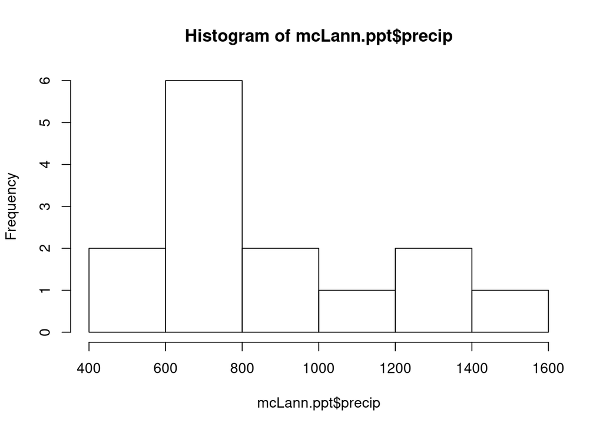

```r
# mcL ann
mcLann.ppt <- all.CTI.wtryr %>% filter(site == "McL Ann")
hist(mcLann.ppt$precip)
```

```r
mcLann.ppt.lm <- lm(precip ~ year,
                    data = mcLann.ppt)
summary(mcLann.ppt.lm)
```

```
##
## Call:
## lm(formula = precip ~ year, data = mcLann.ppt)
##
## Residuals:
##    Min     1Q Median     3Q    Max
## -423.4 -205.6 -152.1  239.0  646.0
##
## Coefficients:
##              Estimate Std. Error t value Pr(>|t|)
## (Intercept) -27035.17   46861.53  -0.577    0.575
## year            13.87      23.29   0.596    0.562
##
## Residual standard error: 351.2 on 12 degrees of freedom
## Multiple R-squared:  0.02873,    Adjusted R-squared:  -0.05221
## F-statistic: 0.355 on 1 and 12 DF,  p-value: 0.5624
```

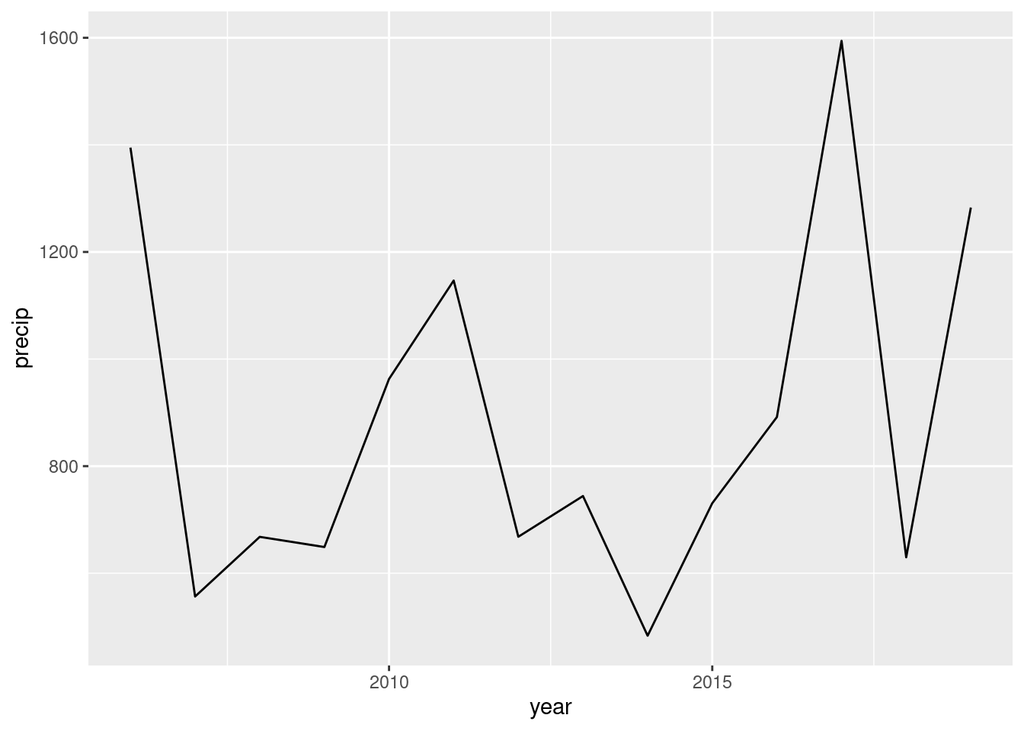

```r
ggplot(mcLann.ppt, aes(x = year, y = precip)) + geom_line()
```

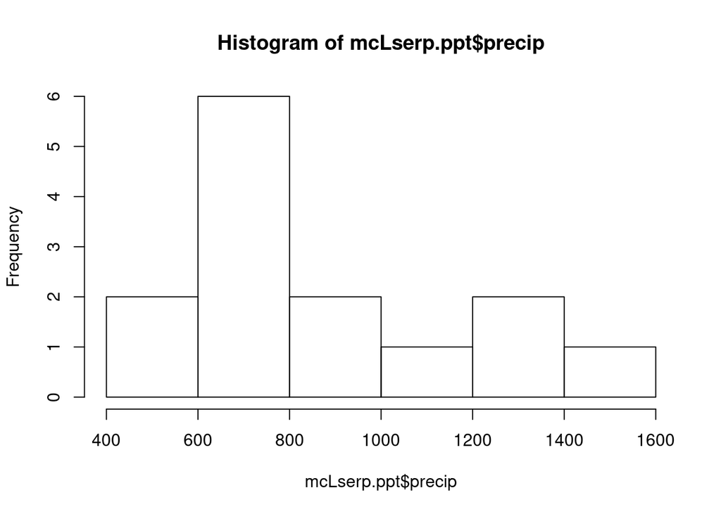

```r
# mcL serp
mcLserp.ppt <- all.CTI.wtryr %>% filter(site == "McL Serp")
hist(mcLserp.ppt$precip)
```

```r
mcLserp.ppt.lm <- lm(precip ~ year,
                    data = mcLserp.ppt)
summary(mcLserp.ppt.lm)
```

```
##
## Call:
## lm(formula = precip ~ year, data = mcLserp.ppt)
##
## Residuals:
##    Min     1Q Median     3Q    Max
## -423.4 -205.6 -152.1  239.0  646.0
##
## Coefficients:
##              Estimate Std. Error t value Pr(>|t|)
## (Intercept) -27035.17   46861.53  -0.577    0.575
## year            13.87      23.29   0.596    0.562
##
## Residual standard error: 351.2 on 12 degrees of freedom
## Multiple R-squared:  0.02873,    Adjusted R-squared:  -0.05221
## F-statistic: 0.355 on 1 and 12 DF,  p-value: 0.5624
```

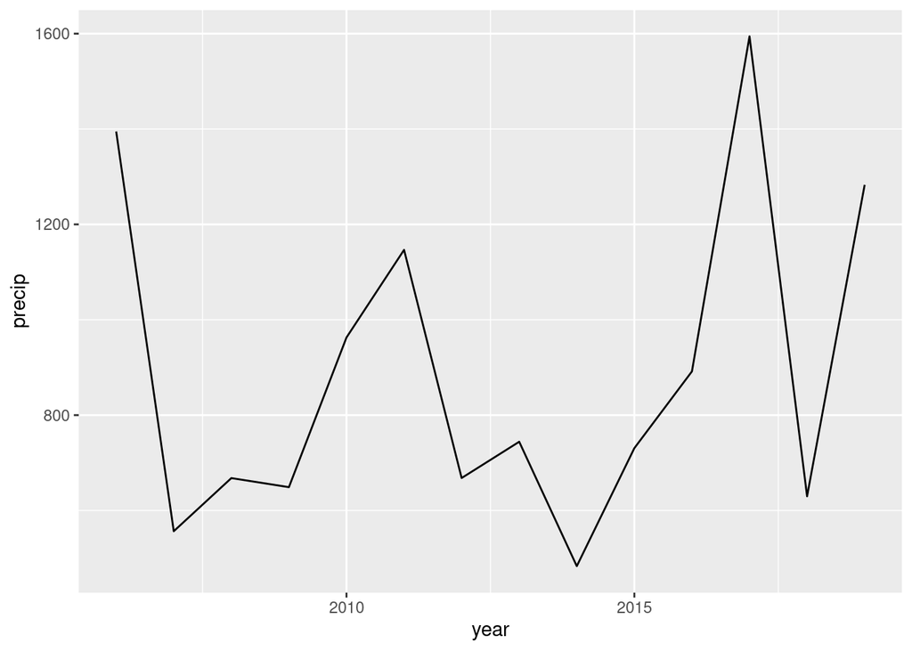

```r
ggplot(mcLserp.ppt, aes(x = year, y = precip)) + geom_line()
```

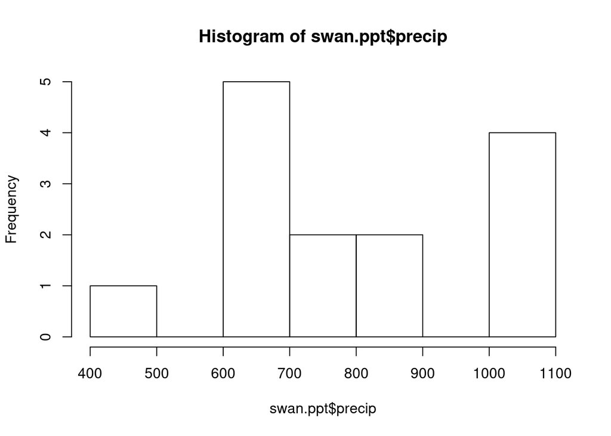

```r
# swanton
swan.ppt <- all.CTI.wtryr %>% filter(site == "Swanton")
hist(swan.ppt$precip)
```

```r
swan.ppt.lm <- lm(precip ~ year,
                    data = swan.ppt)
summary(swan.ppt.lm)
```

```
##
## Call:
## lm(formula = precip ~ year, data = swan.ppt)
##
## Residuals:
##     Min      1Q  Median      3Q     Max
## -303.58 -121.37  -60.62  159.50  280.85
##
## Coefficients:
##              Estimate Std. Error t value Pr(>|t|)
## (Intercept)  7723.960  25252.518   0.306    0.765
## year           -3.451     12.592  -0.274    0.789
##
## Residual standard error: 189.9 on 12 degrees of freedom
## Multiple R-squared:  0.006219,   Adjusted R-squared:  -0.0766
## F-statistic: 0.0751 on 1 and 12 DF,  p-value: 0.7887
```

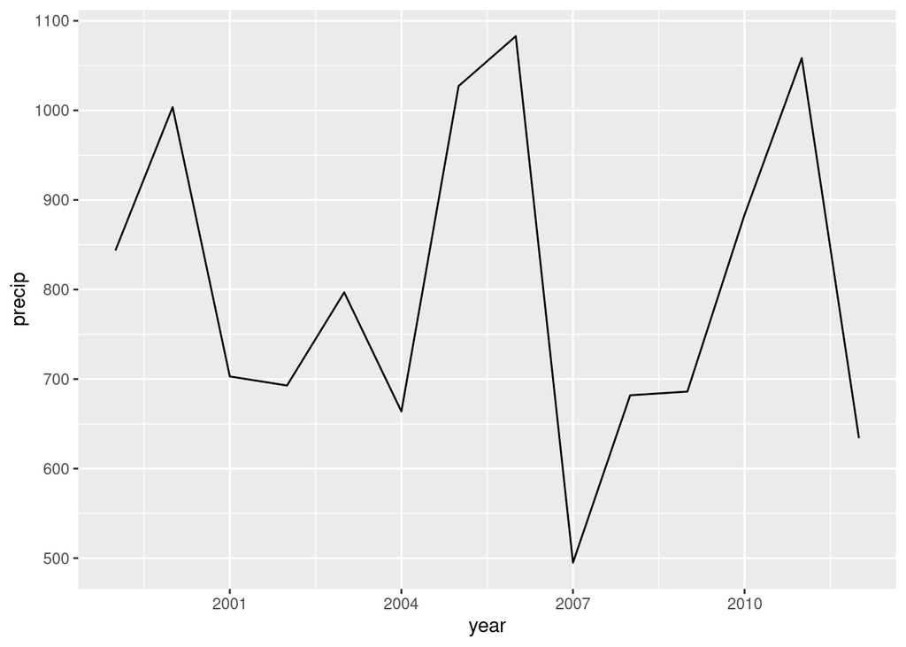

```r
ggplot(swan.ppt, aes(x = year, y = precip)) + geom_line()
```

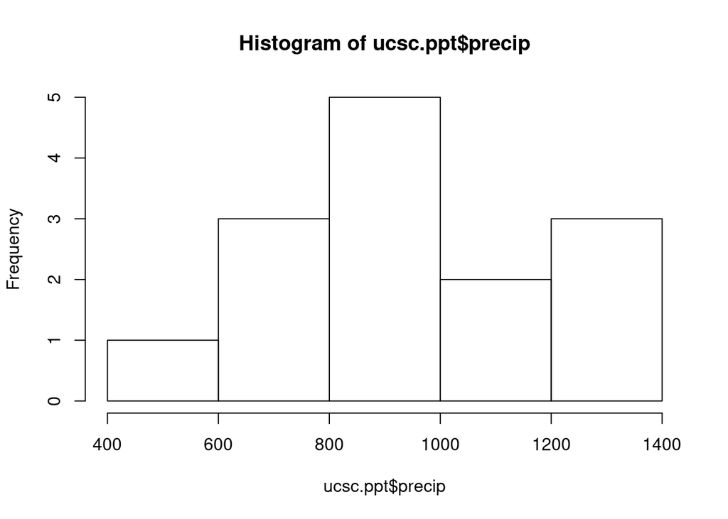

```r
# ucsc
ucsc.ppt <- all.CTI.wtryr %>% filter(site == "UCSC")
hist(ucsc.ppt$precip)
```

```r
ucsc.ppt.lm <- lm(precip ~ year,
                    data = ucsc.ppt)
summary(ucsc.ppt.lm)
```

```
##
## Call:
## lm(formula = precip ~ year, data = ucsc.ppt)
##
## Residuals:
##     Min      1Q  Median      3Q     Max
## -402.97 -162.17  -43.71  161.97  345.87
##
## Coefficients:
##              Estimate Std. Error t value Pr(>|t|)
## (Intercept) 18155.040  32207.912   0.564    0.583
## year           -8.573     16.060  -0.534    0.603
##
## Residual standard error: 242.2 on 12 degrees of freedom
## Multiple R-squared:  0.0232, Adjusted R-squared:  -0.0582
## F-statistic: 0.285 on 1 and 12 DF,  p-value: 0.6032
```

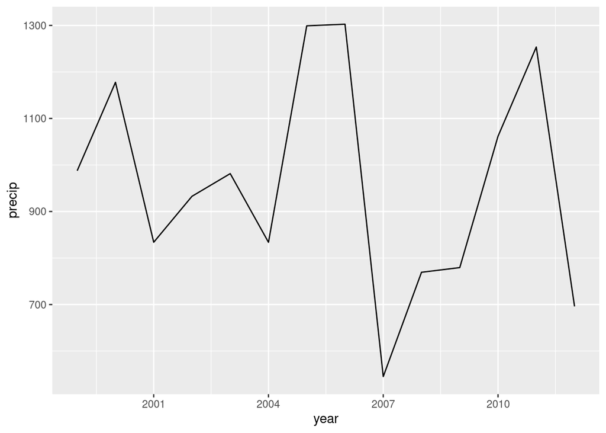

```r
ggplot(ucsc.ppt, aes(x = year, y = precip)) + geom_line()
```

### Wintertime precip

So, there’s pretty clearly no change in overall annual precip. However, never one to give up, I’ll also check the wintertime precip (which Dr. Harrison has found is important in her models).

```r
# angelo
ang.ppt <- win.ppt %>% filter(site == "Angelo")
ang.ppt.lm <- lm(precip ~ year,
                    data = ang.ppt)
summary(ang.ppt.lm)
```

```
##
## Call:
## lm(formula = precip ~ year, data = ang.ppt)
##
## Residuals:
##     Min      1Q  Median      3Q     Max
## -693.82 -241.24   11.06  236.13  561.16
##
## Coefficients:
##              Estimate Std. Error t value Pr(>|t|)
## (Intercept) 103514.22   42173.72   2.454   0.0290 *
## year           -51.03      20.99  -2.431   0.0303 *
## ---
## Signif. codes:  0 '***' 0.001 '**' 0.01 '*' 0.05 '.' 0.1 ' ' 1
##
## Residual standard error: 351.3 on 13 degrees of freedom
## Multiple R-squared:  0.3125, Adjusted R-squared:  0.2596
## F-statistic:  5.91 on 1 and 13 DF,  p-value: 0.03028
```

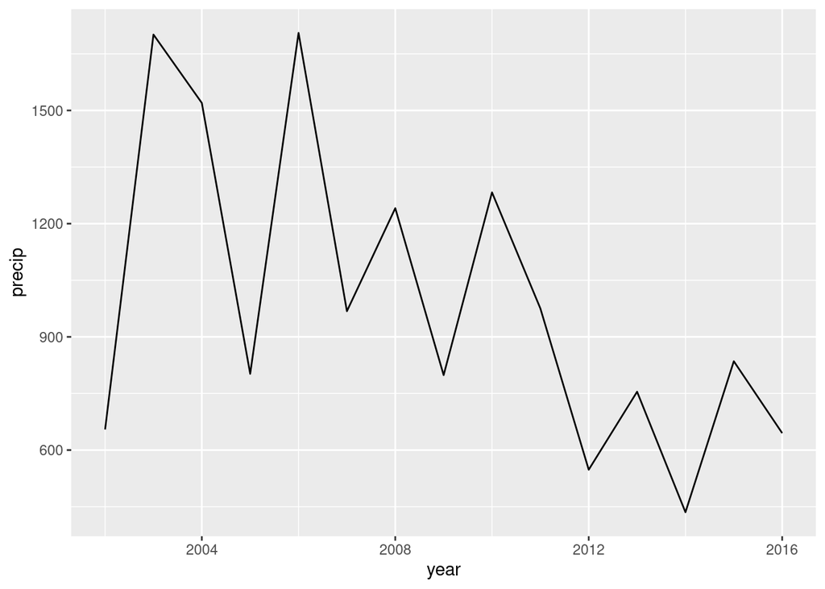

```r
ggplot(ang.ppt, aes(x = year, y = precip)) + geom_line()
```

```r
# carrizo
car.ppt <- win.ppt %>% filter(site == "Carrizo")
car.ppt.lm <- lm(precip ~ year,
                    data = car.ppt)
summary(car.ppt.lm)
```

```
##
## Call:
## lm(formula = precip ~ year, data = car.ppt)
##
## Residuals:
##    Min     1Q Median     3Q    Max
## -81.06 -64.51 -29.03  46.02 199.47
##
## Coefficients:
##              Estimate Std. Error t value Pr(>|t|)
## (Intercept)  8154.392  13021.269   0.626    0.544
## year           -4.002      6.469  -0.619    0.549
##
## Residual standard error: 87.27 on 11 degrees of freedom
## Multiple R-squared:  0.03362,    Adjusted R-squared:  -0.05423
## F-statistic: 0.3827 on 1 and 11 DF,  p-value: 0.5487
```

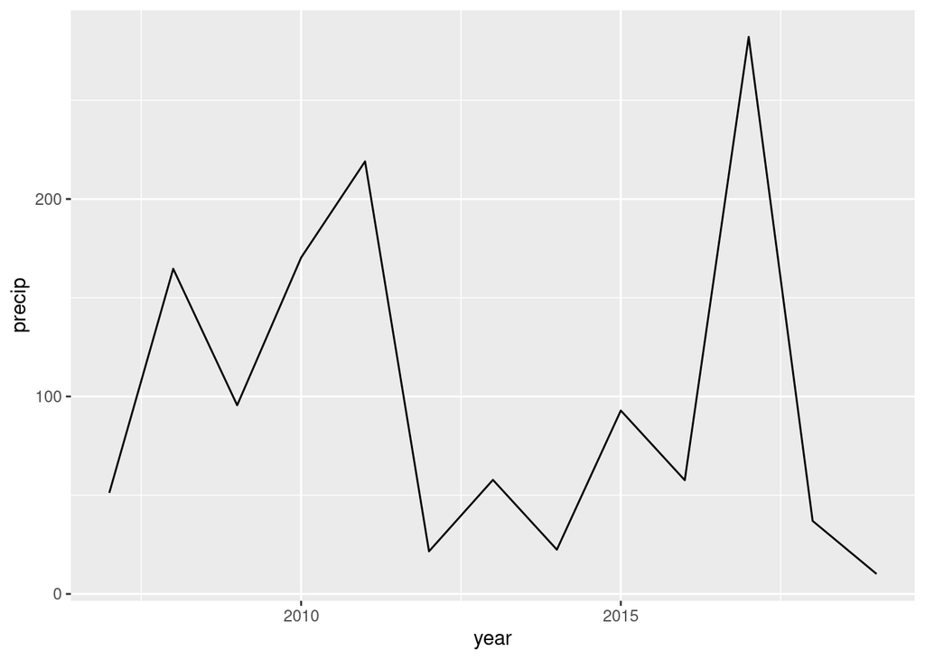

```r
ggplot(car.ppt, aes(x = year, y = precip)) + geom_line()
```

```r
# elkhorn
elk.ppt <- win.ppt %>% filter(site == "Elkhorn")
elk.ppt.lm <- lm(precip ~ year,
                    data = elk.ppt)
summary(elk.ppt.lm)
```

```
##
## Call:
## lm(formula = precip ~ year, data = elk.ppt)
##
## Residuals:
##     Min      1Q  Median      3Q     Max
## -188.13 -112.01   -9.71   71.68  387.17
##
## Coefficients:
##             Estimate Std. Error t value Pr(>|t|)
## (Intercept) 3393.086   9533.004   0.356    0.726
## year          -1.559      4.745  -0.329    0.746
##
## Residual standard error: 131.7 on 19 degrees of freedom
## Multiple R-squared:  0.005649,   Adjusted R-squared:  -0.04669
## F-statistic: 0.1079 on 1 and 19 DF,  p-value: 0.7461
```

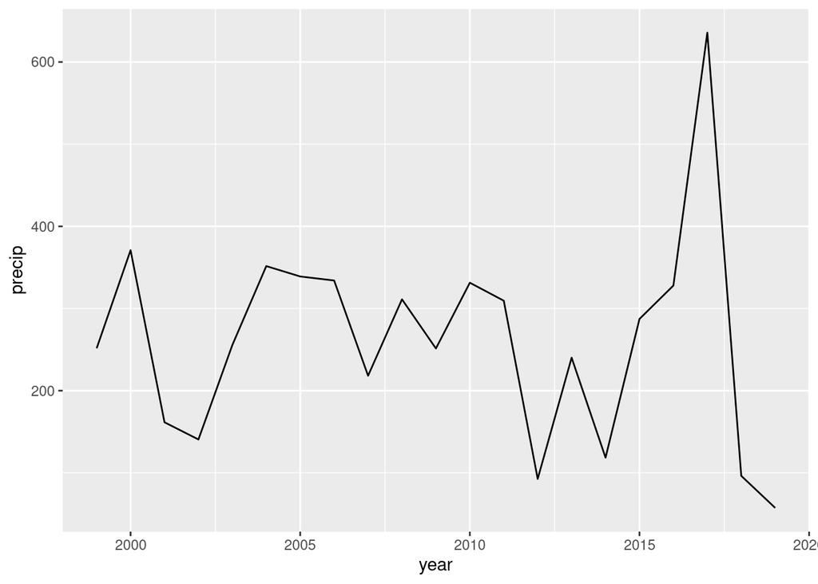

```r
ggplot(elk.ppt, aes(x = year, y = precip)) + geom_line()
```

```r
# jasper
jasp.ppt <- win.ppt %>% filter(site == "Jasper")
jasp.ppt.lm <- lm(precip ~ year,
                    data = jasp.ppt)
summary(jasp.ppt.lm)
```

```
##
## Call:
## lm(formula = precip ~ year, data = jasp.ppt)
##
## Residuals:
##     Min      1Q  Median      3Q     Max
## -207.57  -97.51    7.13   84.11  388.05
##
## Coefficients:
##             Estimate Std. Error t value Pr(>|t|)
## (Intercept) 4065.128   5014.825   0.811    0.424
## year          -1.871      2.508  -0.746    0.461
##
## Residual standard error: 143.5 on 32 degrees of freedom
## Multiple R-squared:  0.01709,    Adjusted R-squared:  -0.01363
## F-statistic: 0.5564 on 1 and 32 DF,  p-value: 0.4612
```

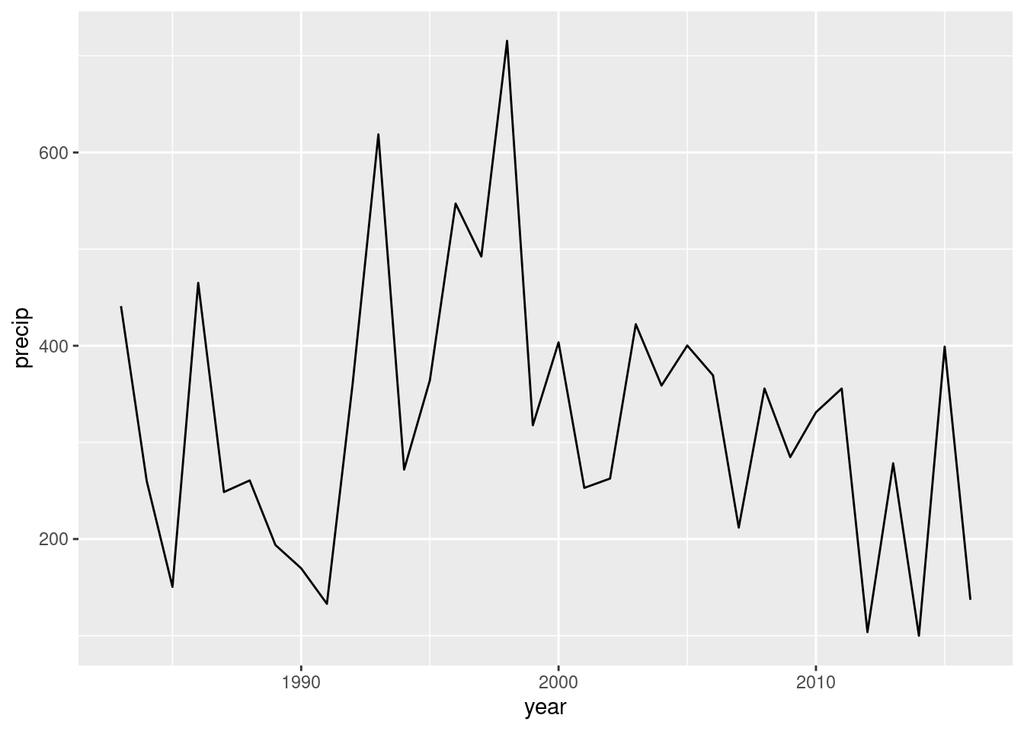

```r
ggplot(jasp.ppt, aes(x = year, y = precip)) + geom_line()
```

```r
# mcL ann
mcLann.ppt <- win.ppt %>% filter(site == "McL Ann")
mcLann.ppt.lm <- lm(precip ~ year,
                    data = mcLann.ppt)
summary(mcLann.ppt.lm)
```

```
##
## Call:
## lm(formula = precip ~ year, data = mcLann.ppt)
##
## Residuals:
##     Min      1Q  Median      3Q     Max
## -343.70 -148.89   -2.58   79.51  614.14
##
## Coefficients:
##              Estimate Std. Error t value Pr(>|t|)
## (Intercept) -21782.94   30108.40  -0.723    0.482
## year            11.05      14.96   0.739    0.473
##
## Residual standard error: 250.3 on 13 degrees of freedom
## Multiple R-squared:  0.04029,    Adjusted R-squared:  -0.03353
## F-statistic: 0.5458 on 1 and 13 DF,  p-value: 0.4732
```

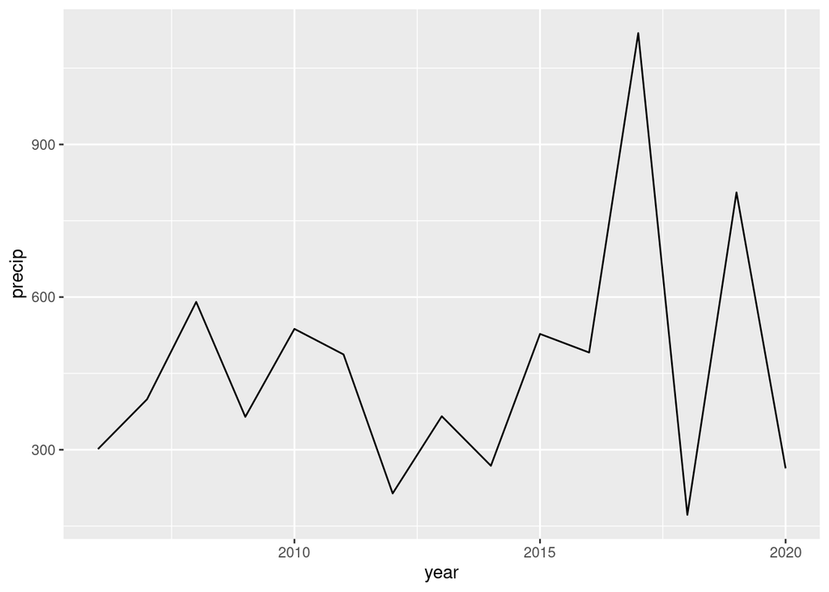

```r
ggplot(mcLann.ppt, aes(x = year, y = precip)) + geom_line()
```

```r
# mcL serp
mcLserp.ppt <- win.ppt %>% filter(site == "McL Serp")
mcLserp.ppt.lm <- lm(precip ~ year,
                    data = mcLserp.ppt)
summary(mcLserp.ppt.lm)
```

```
##
## Call:
## lm(formula = precip ~ year, data = mcLserp.ppt)
##
## Residuals:
##     Min      1Q  Median      3Q     Max
## -343.70 -148.89   -2.58   79.51  614.14
##
## Coefficients:
##              Estimate Std. Error t value Pr(>|t|)
## (Intercept) -21782.94   30108.40  -0.723    0.482
## year            11.05      14.96   0.739    0.473
##
## Residual standard error: 250.3 on 13 degrees of freedom
## Multiple R-squared:  0.04029,    Adjusted R-squared:  -0.03353
## F-statistic: 0.5458 on 1 and 13 DF,  p-value: 0.4732
```

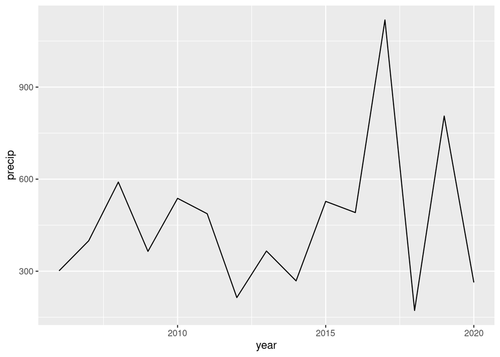

```r
ggplot(mcLserp.ppt, aes(x = year, y = precip)) + geom_line()
```

```r
# swanton
swan.ppt <- win.ppt %>% filter(site == "Swanton")
swan.ppt.lm <- lm(precip ~ year,
                    data = swan.ppt)
summary(swan.ppt.lm)
```

```
##
## Call:
## lm(formula = precip ~ year, data = swan.ppt)
##
## Residuals:
##      Min       1Q   Median       3Q      Max
## -229.795 -107.478    3.925   71.572  177.984
##
## Coefficients:
##              Estimate Std. Error t value Pr(>|t|)
## (Intercept) 25417.999  14698.646   1.729    0.107
## year          -12.438      7.327  -1.697    0.113
##
## Residual standard error: 122.6 on 13 degrees of freedom
## Multiple R-squared:  0.1814, Adjusted R-squared:  0.1185
## F-statistic: 2.881 on 1 and 13 DF,  p-value: 0.1134
```

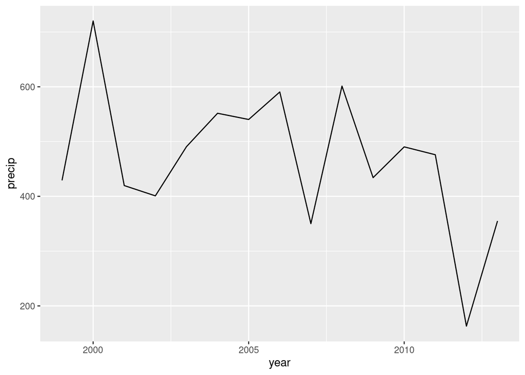

```r
ggplot(swan.ppt, aes(x = year, y = precip)) + geom_line()
```

```r
# ucsc
ucsc.ppt <- win.ppt %>% filter(site == "UCSC")
ucsc.ppt.lm <- lm(precip ~ year,
                    data = ucsc.ppt)
summary(ucsc.ppt.lm)
```

```
##
## Call:
## lm(formula = precip ~ year, data = ucsc.ppt)
##
## Residuals:
##     Min      1Q  Median      3Q     Max
## -283.14 -116.92   11.35  109.52  193.34
##
## Coefficients:
##             Estimate Std. Error t value Pr(>|t|)
## (Intercept) 31601.39   18615.31   1.698    0.113
## year          -15.47       9.28  -1.668    0.119
##
## Residual standard error: 155.3 on 13 degrees of freedom
## Multiple R-squared:  0.1762, Adjusted R-squared:  0.1128
## F-statistic: 2.781 on 1 and 13 DF,  p-value: 0.1193
```

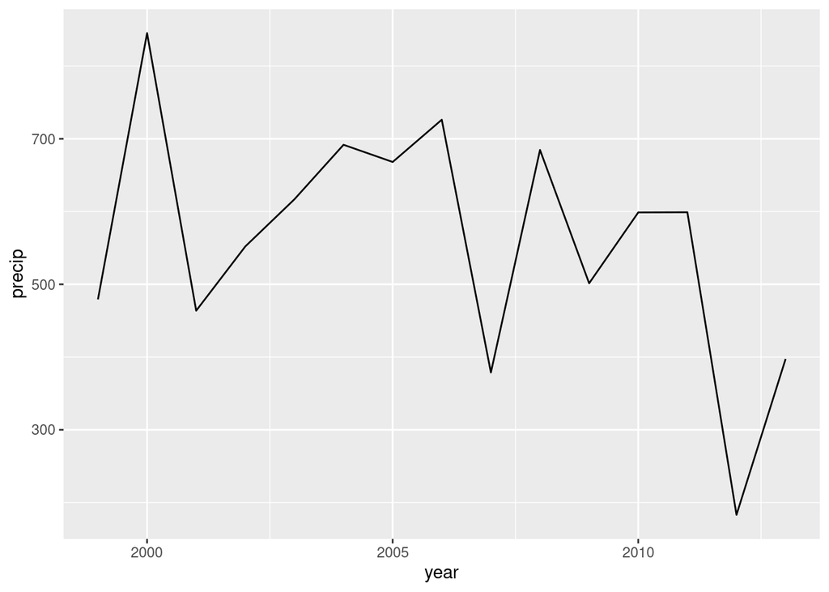

```r
ggplot(ucsc.ppt, aes(x = year, y = precip)) + geom_line()
```

## Temperature Analysis

```r
# angelo
ang.tmin <- all.CTI.wtryr %>% filter(site == "Angelo")
ang.tmin.lm <- lm(tmin ~ year,
                    data = ang.tmin)
summary(ang.tmin.lm)
```

```
##
## Call:
## lm(formula = tmin ~ year, data = ang.tmin)
##
## Residuals:
##      Min       1Q   Median       3Q      Max
## -0.75118 -0.32886  0.07013  0.33113  1.32409
##
## Coefficients:
##              Estimate Std. Error t value Pr(>|t|)
## (Intercept) -89.90472   79.48163  -1.131    0.280
## year          0.04758    0.03957   1.202    0.252
##
## Residual standard error: 0.5969 on 12 degrees of freedom
## Multiple R-squared:  0.1075, Adjusted R-squared:  0.03314
## F-statistic: 1.446 on 1 and 12 DF,  p-value: 0.2524
```

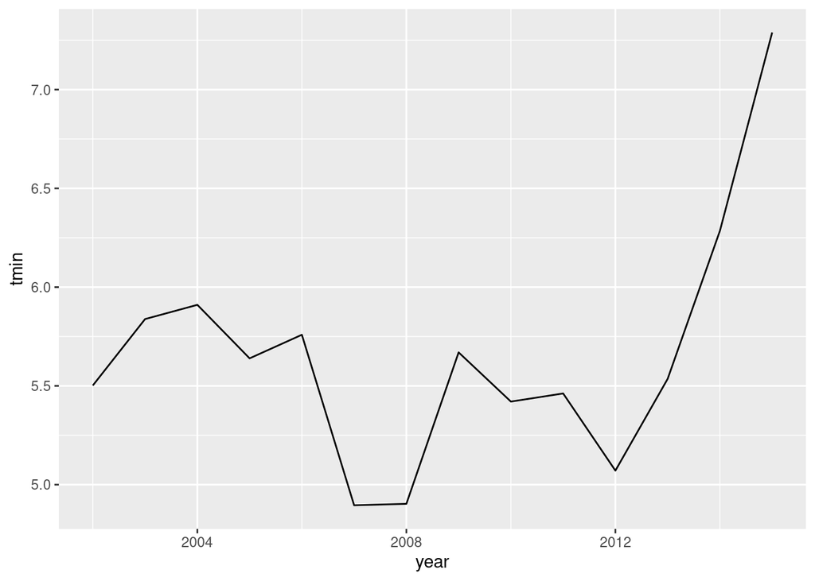

```r
ggplot(ang.tmin, aes(x = year, y = tmin)) + geom_line()
```

```r
# carrizo
car.tmin <- all.CTI.wtryr %>% filter(site == "Carrizo")
car.tmin.lm <- lm(tmin ~ year,
                    data = car.tmin)
summary(car.tmin.lm)
```

```
##
## Call:
## lm(formula = tmin ~ year, data = car.tmin)
##
## Residuals:
##      Min       1Q   Median       3Q      Max
## -0.75002 -0.24434  0.05647  0.24938  0.76786
##
## Coefficients:
##               Estimate Std. Error t value Pr(>|t|)
## (Intercept) -326.77005   74.49692  -4.386  0.00136 **
## year           0.16662    0.03702   4.501  0.00114 **
## ---
## Signif. codes:  0 '***' 0.001 '**' 0.01 '*' 0.05 '.' 0.1 ' ' 1
##
## Residual standard error: 0.4427 on 10 degrees of freedom
## Multiple R-squared:  0.6695, Adjusted R-squared:  0.6365
## F-statistic: 20.26 on 1 and 10 DF,  p-value: 0.001141
```

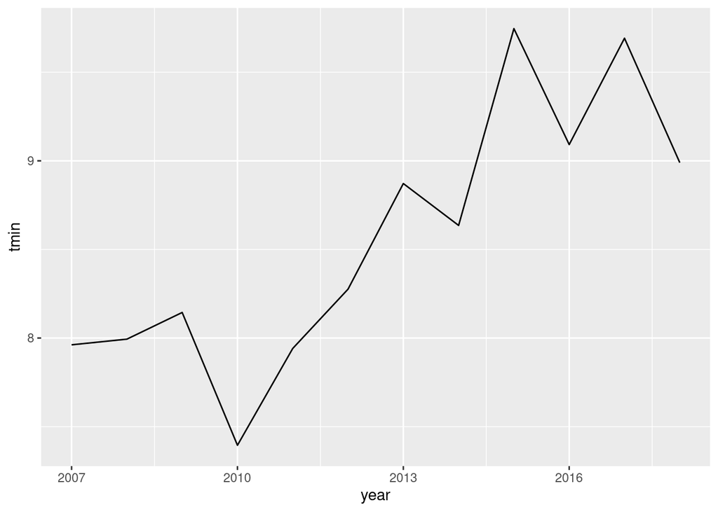

```r
ggplot(car.tmin, aes(x = year, y = tmin)) + geom_line()
```

```r
# elkhorn
elk.tmin <- all.CTI.wtryr %>% filter(site == "Elkhorn")
elk.tmin.lm <- lm(tmin ~ year,
                    data = elk.tmin)
summary(elk.tmin.lm)
```

```
##
## Call:
## lm(formula = tmin ~ year, data = elk.tmin)
##
## Residuals:
##      Min       1Q   Median       3Q      Max
## -1.06967 -0.43143 -0.01107  0.42834  1.23777
##
## Coefficients:
##              Estimate Std. Error t value Pr(>|t|)
## (Intercept) -71.11729   45.69563  -1.556   0.1370
## year          0.03960    0.02275   1.741   0.0988 .
## ---
## Signif. codes:  0 '***' 0.001 '**' 0.01 '*' 0.05 '.' 0.1 ' ' 1
##
## Residual standard error: 0.5867 on 18 degrees of freedom
## Multiple R-squared:  0.1441, Adjusted R-squared:  0.09654
## F-statistic:  3.03 on 1 and 18 DF,  p-value: 0.09879
```

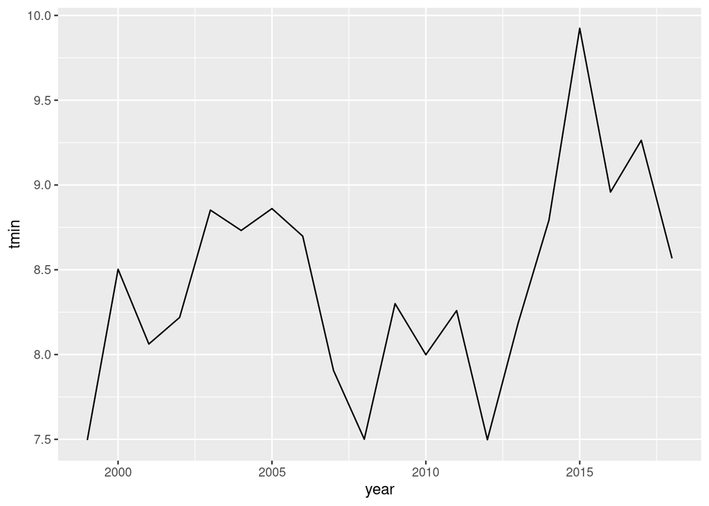

```r
ggplot(elk.tmin, aes(x = year, y = tmin)) + geom_line()
```

```r
# jasper
jasp.tmin <- all.CTI.wtryr %>% filter(site == "Jasper")
jasp.tmin.lm <- lm(tmin ~ year,
                    data = jasp.tmin)
summary(jasp.tmin.lm)
```

```
##
## Call:
## lm(formula = tmin ~ year, data = jasp.tmin)
##
## Residuals:
##      Min       1Q   Median       3Q      Max
## -1.24876 -0.30187 -0.02734  0.32837  1.32004
##
## Coefficients:
##               Estimate Std. Error t value Pr(>|t|)
## (Intercept) -84.817217  18.054793  -4.698 5.10e-05 ***
## year          0.046486   0.009032   5.147 1.41e-05 ***
## ---
## Signif. codes:  0 '***' 0.001 '**' 0.01 '*' 0.05 '.' 0.1 ' ' 1
##
## Residual standard error: 0.494 on 31 degrees of freedom
## Multiple R-squared:  0.4608, Adjusted R-squared:  0.4434
## F-statistic: 26.49 on 1 and 31 DF,  p-value: 1.41e-05
```

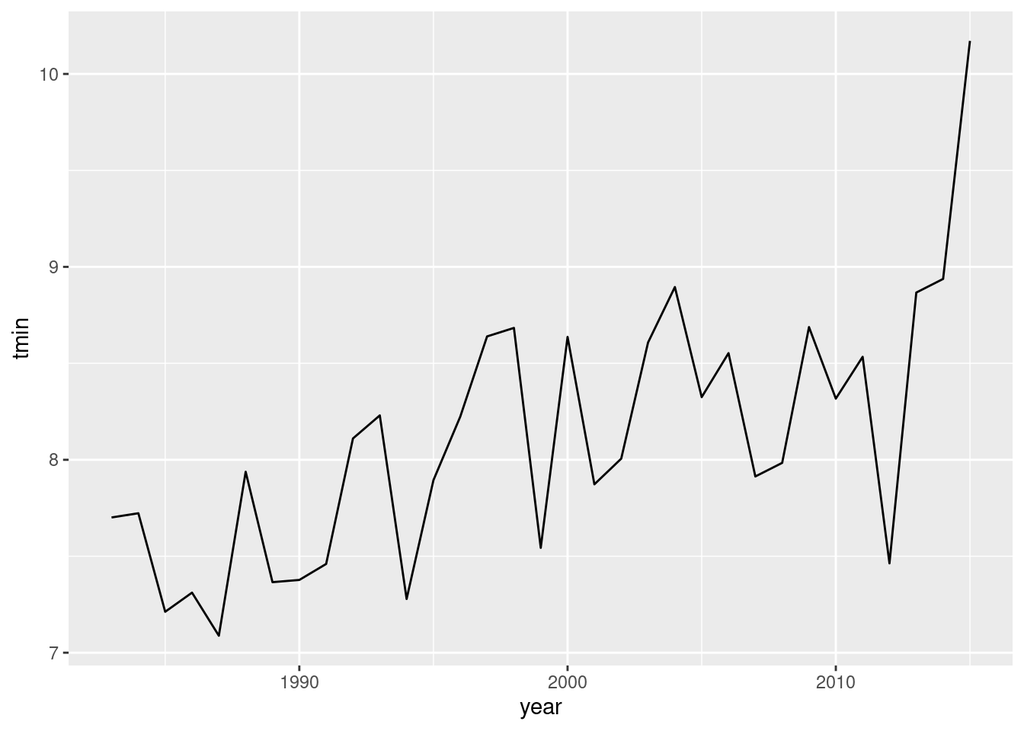

```r
ggplot(jasp.tmin, aes(x = year, y = tmin)) + geom_line()
```

```r
# mcL ann
mcLann.tmin <- all.CTI.wtryr %>% filter(site == "McL Ann")
mcLann.tmin.lm <- lm(tmin ~ year,
                    data = mcLann.tmin)
summary(mcLann.tmin.lm)
```

```
##
## Call:
## lm(formula = tmin ~ year, data = mcLann.tmin)
##
## Residuals:
##     Min      1Q  Median      3Q     Max
## -0.9325 -0.5556  0.1447  0.4384  0.7183
##
## Coefficients:
##               Estimate Std. Error t value Pr(>|t|)
## (Intercept) -303.85400   82.56904   -3.68  0.00315 **
## year           0.15509    0.04103    3.78  0.00262 **
## ---
## Signif. codes:  0 '***' 0.001 '**' 0.01 '*' 0.05 '.' 0.1 ' ' 1
##
## Residual standard error: 0.6188 on 12 degrees of freedom
## Multiple R-squared:  0.5436, Adjusted R-squared:  0.5055
## F-statistic: 14.29 on 1 and 12 DF,  p-value: 0.002623
```

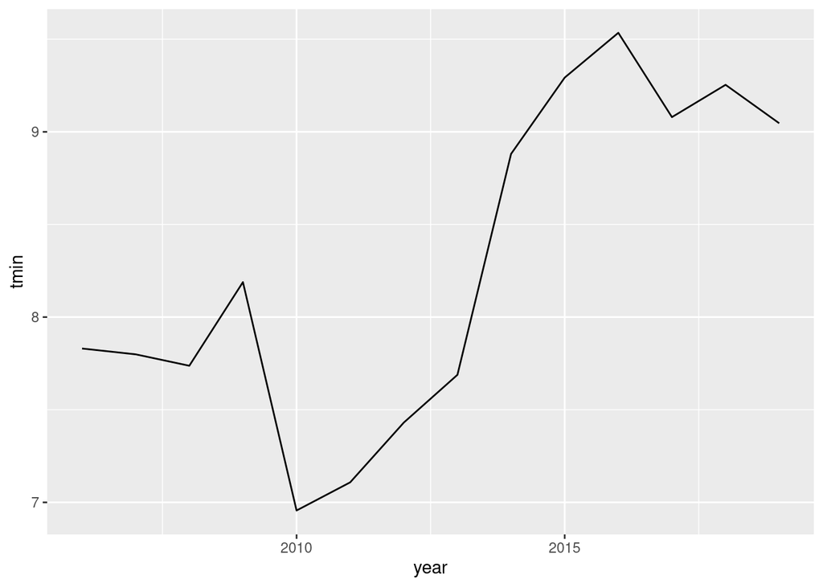

```r
ggplot(mcLann.tmin, aes(x = year, y = tmin)) + geom_line()
```